[figure not shown]

# Poverty Exposure

```r
options(scipen = 999)

library(tidyverse)
library(censusapi)
library(urbnthemes)
library(reactable)

set_urbn_defaults(style = "print")

source(here::here("R", "census_api_key.R"))
source(here::here("R", "get_vars.R"))
```

## 2018 ACS 5-Year Estimates

**Index:** the share of people who are poor in a county who live in census tracts with poverty rates over 40%. If a county’s overall poverty rate is 20% but people experiencing poverty are spread out evenly across all census tracts, the index would equal 0; if they were heavily concentrated in certain tracts, the index would approach 1.

All numbers come for the Census API. The documentation for the Census API is available [here](https://api.census.gov/data/2018/acs/acs5/profile/variables.html).

### 1. Pull people and poverty rates for Census tracts.

```r
vars <- c(
  "DP03_0128PE", # Estimate!!PERCENTAGE OF FAMILIES AND PEOPLE WHOSE INCOME IN
                 #THE PAST 12 MONTHS IS BELOW THE POVERTY LEVEL!!All people
  "DP03_0128PM"
)

# pull Census tracts for 2018
tracts <- get_vars(year = 2018, vars = vars, geography = "tract")

# rename the variables
tracts <- tracts %>%
  rename(people = B01003_001E,
         poverty = DP03_0128PE,
         poverty_moe = DP03_0128PM)
```

```r
tracts %>%
  filter(poverty == -666666666) %>%
  count()
```

```
## # A tibble: 1 x 1
##       n
##   <int>
## 1   792
```

```r
tracts %>%
  filter(poverty == -666666666) %>%
  summarize(sum(people))
```

```
## # A tibble: 1 x 1
##   `sum(people)`
##           <dbl>
## 1        381603
```

We replace the suppressed values with zeros. This will only affect the count of people who experience poverty in high-poverty areas. There is one county, outlined later, that has issues.

```r
tracts <- tracts %>%
  mutate(poverty = if_else(poverty == -666666666, 0, poverty))
```

Check the number of people. 323 million seems about right for 2018.

```r
tracts %>%
  summarize(sum(people))
```

```
## # A tibble: 1 x 1
##   `sum(people)`
##           <dbl>
## 1     322903030
```

### 2. Count the number of people in poverty who live in Census tracts with poverty > 40% in each county.

```r
tracts <- tracts %>%
  mutate(high_poverty = if_else(poverty > 40, people * poverty * 0.01, 0))

counties_summary <- tracts %>%
  group_by(state, county) %>%
  summarize(people = sum(people),
            high_poverty = sum(high_poverty),
            tracts = n()) %>%
  ungroup()
```

### 3. Count the number of people in poverty who live in each county.

```r
counties <- get_vars(year = 2018, vars = vars, geography = "county") %>%
  rename(people_county = B01003_001E,
         poverty_rate_county = DP03_0128PE,
         poverty_rate_county_moe = DP03_0128PM)
```

Rio Arriba County, New Mexico was the only county with a suppressed poverty level in 2018. Its tracts are also suppressed with code -888888888. It will need to be a missing value.

```r
tracts %>%
  filter(state == "35", county == "039")
```

```
## # A tibble: 9 x 7
##   state county tract  people    poverty poverty_moe high_poverty
##   <chr> <chr>  <chr>   <dbl>      <dbl>       <dbl>        <dbl>
## 1 35    039    000300   5834 -888888888  -888888888            0
## 2 35    039    000400   4159 -888888888  -888888888            0
## 3 35    039    940800   5247 -888888888  -888888888            0
## 4 35    039    000200   3664 -888888888  -888888888            0
## 5 35    039    940700   3510 -888888888  -888888888            0
## 6 35    039    000100   3037 -888888888  -888888888            0
## 7 35    039    000500   3662 -888888888  -888888888            0
## 8 35    039    941000   3653 -888888888  -888888888            0
## 9 35    039    944100   6541 -888888888  -888888888            0
```

```r
counties <- counties %>%
  mutate(poverty_rate_county = ifelse(state == "35" & county == "039", NA, poverty_rate_county))
```

### 4. Join and test the summarized tract data and the county data.

Join data and calculate the poverty exposure metric.

This should be a one-to-one match between the 3142 in `counties` and 3142 in `counties_summary`.

```r
counties_joined <- left_join(counties, counties_summary, by = c("state", "county"))
```

The anti-join is empty.

```r
stopifnot(
  nrow(anti_join(counties, counties_summary, by = c("state", "county"))) == 0
)
```

Check population sums

```r
stopifnot(
  counties_joined %>%
    filter(people_county != people) %>%
    nrow() == 0
)
```

```r
counties_joined <- counties_joined %>%
  mutate(poverty_county = people_county * poverty_rate_county * 0.01)

counties_joined <- counties_joined %>%
  mutate(poverty_exposure = high_poverty / poverty_county)

counties_joined %>%
  arrange(desc(poverty_exposure))
```

```
## # A tibble: 3,142 x 10
##    state county people_county poverty_rate_co… poverty_rate_co… people
##    <chr> <chr>          <dbl>            <dbl>            <dbl>  <dbl>
##  1 17    087            12602             11.8              2.3  12602
##  2 02    158             8198             40.5              1.8   8198
##  3 13    061             3001             41.1              8.6   3001
##  4 28    055             1328             41.7             10.7   1328
##  5 46    095             2055             48.3              7.1   2055
##  6 46    137             2814             41                3.9   2814
##  7 46    121            10146             55.1              4.7  10146
##  8 46    031             4168             44.3              2.9   4168
##  9 28    063             7346             49.7             10.1   7346
## 10 19    169            96922             21.5              1.3  96922
## # … with 3,132 more rows, and 4 more variables: high_poverty <dbl>,
## #   tracts <int>, poverty_county <dbl>, poverty_exposure <dbl>
```

The only missing value is for Rio Arriba County, New Mexico.

```r
counties_joined %>%
  filter(is.na(poverty_exposure))
```

```
## # A tibble: 1 x 10
##   state county people_county poverty_rate_co… poverty_rate_co… people
##   <chr> <chr>          <dbl>            <dbl>            <dbl>  <dbl>
## 1 35    039            39307               NA       -888888888  39307
## # … with 4 more variables: high_poverty <dbl>, tracts <int>,
## #   poverty_county <dbl>, poverty_exposure <dbl>
```

### 6. Validation

The table shows the calculated metrics. Click on the variable columns to sort the table.

| FIPS | tracts | poverty_rate_county | poverty_exposure |
| --- | --- | --- | --- |
| 01099 | 7 | 30.9 | 0.216 |
| 01079 | 9 | 16.8 | 0 |
| 01081 | 27 | 21.4 | 0.341 |
| 01107 | 5 | 23.5 | 0 |
| 01119 | 4 | 31.3 | 0 |
| 01023 | 4 | 22.2 | 0 |
| 01091 | 6 | 21.8 | 0 |
| 01113 | 13 | 20.1 | 0.206 |
| 01039 | 14 | 18.3 | 0.092 |
| 01041 | 6 | 15.7 | 0 |

[output cut: 3132 more lines]

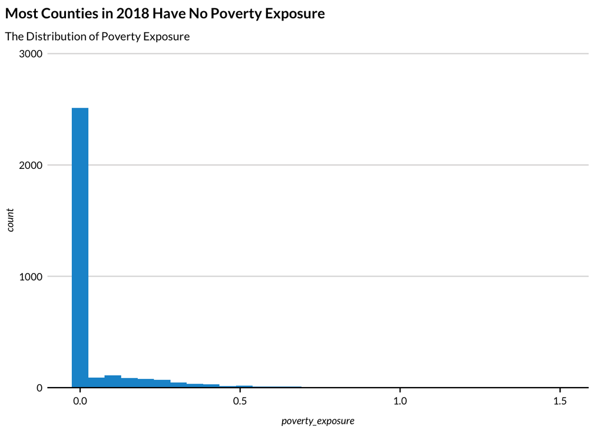

```r
counties_joined %>%
  ggplot(aes(poverty_exposure)) +
  geom_histogram() +
  scale_y_continuous(limits = c(0, NA),
                     expand = expansion(mult = c(0, 0.2))) +
  labs(title = "Most Counties in 2018 Have No Poverty Exposure",
       subtitle = "The Distribution of Poverty Exposure")
```

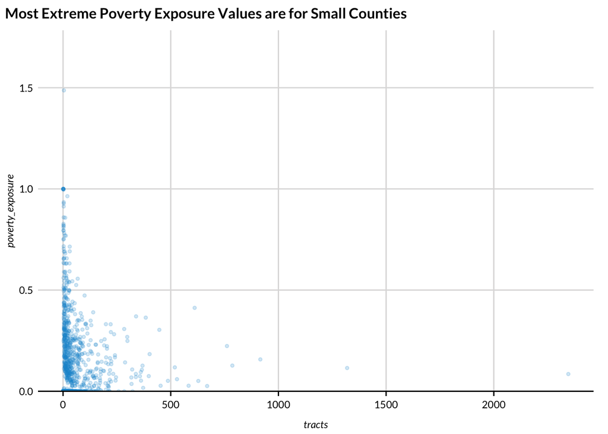

```r
counties_joined %>%
  ggplot(aes(tracts, poverty_exposure)) +
  geom_point(alpha = 0.2,
             size = 1) +
  scale_y_continuous(limits = c(0, NA),
                     expand = expansion(mult = c(0, 0.2))) +
  scatter_grid() +
  labs(title = "Most Extreme Poverty Exposure Values are for Small Counties")
```

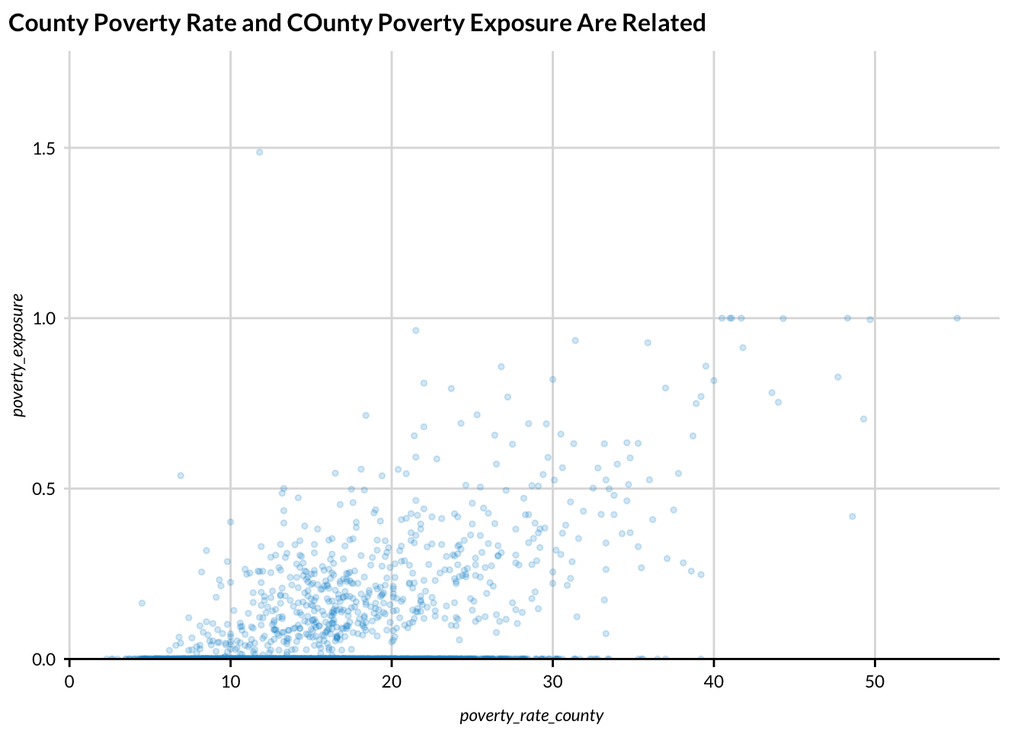

```r
counties_joined %>%
  ggplot(aes(poverty_rate_county, poverty_exposure)) +
  geom_point(alpha = 0.2,
             size = 1) +
  scale_y_continuous(limits = c(0, NA),
                     expand = expansion(mult = c(0, 0.2))) +
  scatter_grid() +
  labs(title = "County Poverty Rate and COunty Poverty Exposure Are Related")
```

### 7. Outstanding questions

- What value should we give counties consisting of exactly one tract?
- Johnson County, Illinois (FIPS == 17087) has a poverty exposure metric of 1.49. One of its four tracts have a poverty estimate of 100% with a margin of error 0.79.
- What geographic information are we using the join the data?
- For earlier years, do I only pull non-overlapping 5-year estimates?
- How should we account for uncertainty? Should I calculate coefficients of variation before calculating the metric?
- Alternative: report missing values for all counties with poverty rates suppressed in at least one tract?